# Democratizando Machine Learning con R Shiny

Eugenio Grant

2021-01-25

## Antecedentes

Para muchas empresas la utilización de modelos de Machine Learning es un elemento fundamental de ventaja competitiva, por esto se vuelve especialmente importante encontrar formas de poner a disposición de sus usuarios la posibilidad de usar estas herramientas.

Sin embargo el proceso de “democratizar” estos modelos enfrenta importantes barreras; su la complejidad implica que en muchos casos se requiere de usuarios con un nivel importante de conocimiento técnico y por otro lado el costo de ponerlos a disposición de todos los usuarios implica costos de desarrollo y el pago de plataformas especializadas.

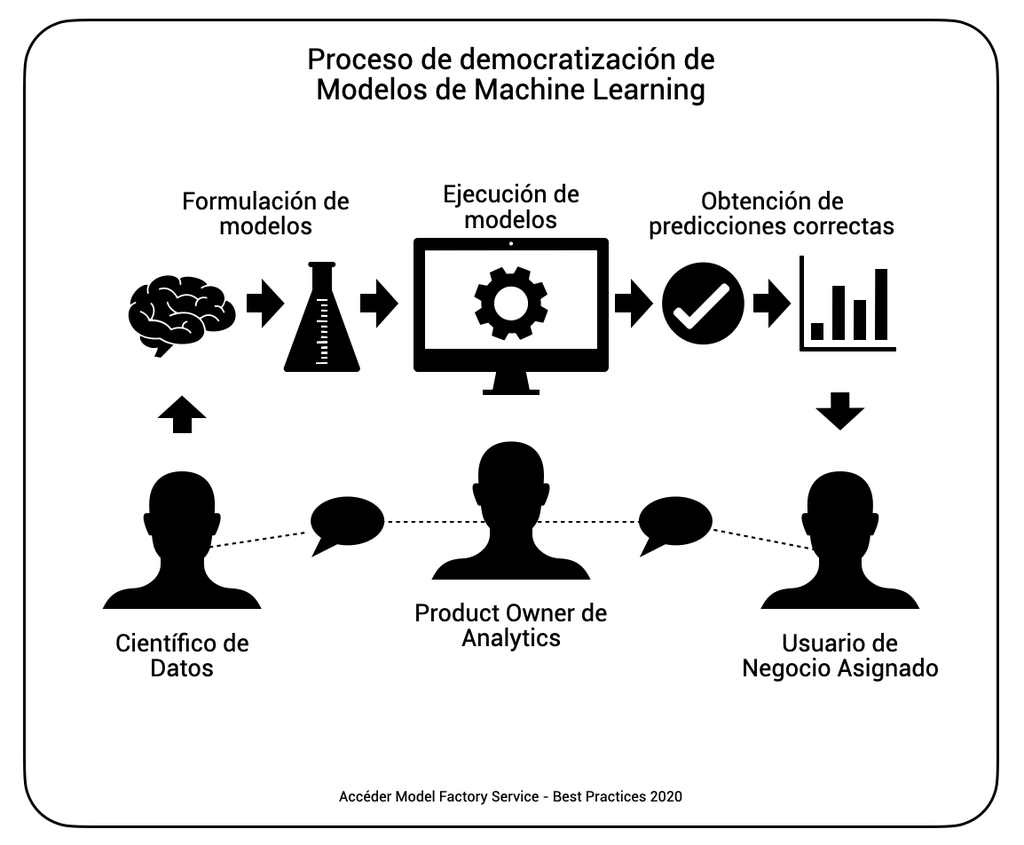

## R & R Shiny

RShiny es una herramienta poderosa para generar productos de datos desde R, ya sean visualzaciones o modelos predictivos. Este paquete tiene una excelente integración con RStudio lo que hace que sea relativamente sencillo crear una aplicación y ejecutarla localmente. Igualmente R Studio ofrece alternativa de pago para despligue de aplicaciones en la nube. Cada una de estas alternativas tiene sus ventajas y desventajas.

## Alternativas de Despliegue (Deployment)

**1. shinyapps.io**: Servicio manejado por RStudio que permite publicación de Apps con un manejo transparente del proceso de DevOps con solo unos cuantos clicks. Servicio limitado en términos de recursos.

**2. Shiny Server Open Source**: Plataforma para generar un servidor web dedicado para el hosting de aplicaciones en R Shiny (on-premise). Sólo soporta un poceso de R por App.

**3. RStudio Connect**: Plataforma de publicación, producto comercial de RStudio y con muchisimas funcionalidades. Costosa en escenarios de prototipado.

**4. Shinyproxy**: Desarrollo Open-Source. Java en el lado de servidor y utiliza docker. Es una herramienta poderosa con características empresariales pero Open Source.

## Veredícto

RStudio Connect es la alternativa más completa en términos de funcionalidad y simplificación de los procesos de desarrollo, pero con licenciamiento de ~USD$10.000/anual se vuelve una barrera, más aún si estamos empezando a prototipar una herramienta específica. Ante esto propongo un “Stack” Open Source

## “Stack Open Source”

[**Shiny**](https://shiny.rstudio.com/) Es un paquete de R para generar aplicaciones Web directamente con R

[**Keycloak**](https://www.keycloak.org/) Es un poderoso producto de software de código abierto para el manejo de autenticación y autorización de usuarios

[**Docker**](https://www.docker.com/) Docker es una plataforma de software que permite crear, probar e implementar aplicaciones rápidamente. Docker empaqueta software en unidades estandarizadas llamadas contenedores que incluyen todo lo necesario para que el software se ejecute, incluidas bibliotecas, herramientas de sistema y código.